# Representaciones dispersas con K-SVD

Dictionary Learning sobre señales de ECG

Carlos Luis Bruzual Roa

Arturo Zabdí Reyes Pérez

Sergio Cesar Villanueva Estrada

Bryan Ezequiel Violante Arriaga

## Contenido

1. El problema
2. Las bases: rango 1, SVD, OMP y K-SVD
3. Aplicación al ECG
4. Resultados

# El problema

## Objetivo

> Implementar K-SVD y obtener una base entrenada para algún tipo de señal, de manera que se pueda comparar la señal original con su reconstrucción a partir de la señal dispersa.
- **Señal elegida:** electrocardiograma
- **Por qué:** se repite, latido tras latido. Un diccionario que *aprenda* esa forma debería describirla con pocas piezas

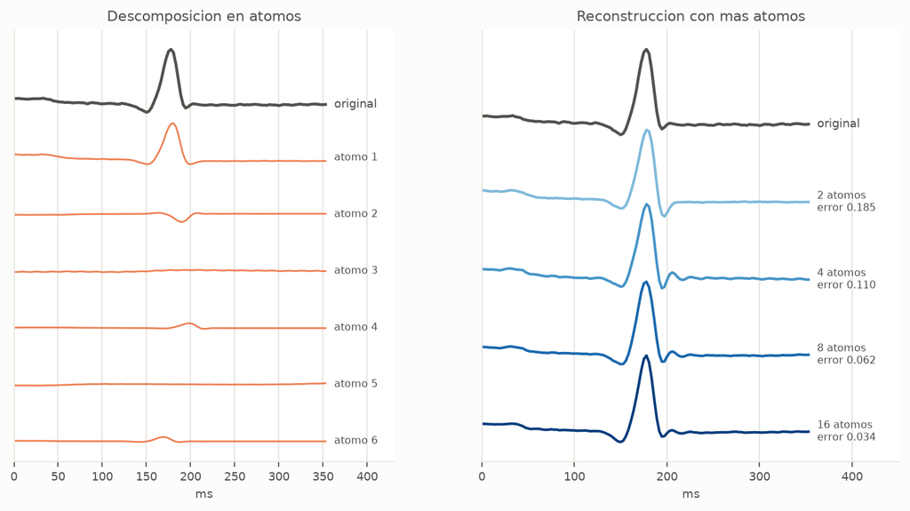

## Una ventana, pocas piezas

una ventana del ECG: 128 números

## Una ventana, pocas piezas

una ventana del ECG: 128 números

1.06 d<sub>204</sub>

-0.21 d<sub>105</sub>

0.11 d<sub>178</sub>

## Una ventana, pocas piezas

1.06 d<sub>204</sub>

-0.21 d<sub>105</sub>

0.11 d<sub>178</sub>

$x \approx 1.06\,d_{204} - 0.21\,d_{105} + 0.11\,d_{178}$

3 números en lugar de 128, con error relativo de **0.150**

## En forma de matrices

[figure not shown]

$x$  
$128 \times 1$

$\approx$

$D$, el diccionario: $128 \times 256$  
cada columna es un átomo

$\alpha$  
$256 \times 1$

De 256 pesos, casi todos valen **cero**: solo trabajan unos cuantos átomos.

# Las bases

## Rango 1: columna por fila

2

1

3

1

2

3

2

4

6

1

2

3

3

6

9

$u$

$v^{\mathsf T}$

Una columna por una fila da una matriz donde **todas las columnas son múltiplos de la misma**.

Eso es una matriz de **rango 1**: tiene una sola dirección genuina.

En K-SVD, un átomo por sus pesos, $d_j\,\alpha_j^{\mathsf T}$, es justo esto. **Siempre es de rango 1.**

## La SVD como suma de piezas de rango 1

Toda matriz se descompone como $A = U \Sigma V^{\mathsf T}$, y eso se puede leer como una suma:

$$A = \sigma_1\, u_1 v_1^{\mathsf T} + \sigma_2\, u_2 v_2^{\mathsf T} +
\sigma_3\, u_3 v_3^{\mathsf T} + \cdots
\qquad \sigma_1 \ge \sigma_2 \ge \sigma_3 \ge \cdots$$

Cada pieza es de rango 1, y vienen ordenadas de la que más pesa a la que menos.

**Teorema de Eckart-Young.** Quedarse con las primeras $k$ piezas da la **mejor aproximación de rango $k$**: ninguna otra matriz de rango $k$ queda más cerca. Y lo que se pierde se sabe de antemano:

$$\lVert A - A_k \rVert^2 = \sigma_{k+1}^2 + \sigma_{k+2}^2 + \cdots$$

## OMP: cada ventana escoge sus átomos

**Algoritmo 1** Orthogonal Matching Pursuit

**Requiere:** diccionario $D$, ventana $x$, error objetivo $\varepsilon = 0.1$, tope de 16 átomos

1:$r \leftarrow x$, $\quad S \leftarrow \emptyset$  
2:**mientras** $\lVert r \rVert / \lVert x \rVert > \varepsilon$ **hacer**  
3:$i \leftarrow \arg\max_i \lvert d_i^{\mathsf T} r \rvert$ escoger el átomo más parecido a lo que falta  
4:$S \leftarrow S \cup \{i\}$  
5:$\alpha_S \leftarrow$ mínimos cuadrados de $x$ sobre $D_S$ reajustar **todos** los pesos  
6:$r \leftarrow x - D_S\,\alpha_S$  
7:**devolver** $\alpha$

El paso 5 es el *orthogonal* del nombre: deja el residual perpendicular a todos los átomos escogidos, así que **ninguno se repite**.

## OMP paso a paso: un ejemplo de juguete

Átomos de **3** números (en vez de 128) y **4** átomos (en vez de 256). El procedimiento es exactamente el mismo.

v₁

v₂

muestra 1

1

0.9

muestra 2

1

1

muestra 3

0.5

0

**X** · 3 × 2  
filas: muestras  
columnas: ventanas

≈

A

B

C

E

muestra 1

1

0.6

0

0

muestra 2

0

0.8

0

1

muestra 3

0

0

1

0

**D** · 3 × 4  
filas: muestras  
columnas: átomos

·

v₁

v₂

A

?

?

B

?

?

C

?

?

E

?

?

**α** · 4 × 2  
filas: átomos  
columnas: ventanas

Cada átomo mide 1: $\lVert B \rVert = \sqrt{0.6^2 + 0.8^2} = 1$. OMP para cuando el error relativo $\lVert r \rVert / \lVert x \rVert$ baja de **0.1** (o al llegar a 16 átomos).

En el proyecto: **X** es 128 × 2539, **D** es 128 × 256 y **α** es 256 × 2539. Mismas reglas, solo más grande.

## Ventana 1, vuelta 1

Ventana $x = v_1 = (1,\, 1,\, 0.5)$, con $\lVert x \rVert = 1.5$. Al inicio falta explicar todo: $r = x$ y $S = \{\,\}$.

1Comparar **todos** los átomos con lo que falta: $D^{\mathsf T} r$

muestra 1

muestra 2

muestra 3

átomo A

1

0

0

átomo B

0.6

0.8

0

átomo C

0

0

1

átomo E

0

1

0

$D^{\mathsf T}$ · 4 × 3  
cada fila es un átomo

·

r

muestra 1

1

muestra 2

1

muestra 3

0.5

r = x · 3 × 1

=

parecido

A

1

B

1.4

C

0.5

E

1

$D^{\mathsf T} r$ · 4 × 1  
uno por átomo

Fila de $D^{\mathsf T}$ por $r$ = producto punto:  
$B \cdot r = 0.6(1)+0.8(1)+0(0.5)$  
$= 1.4$  
Gana el mayor |valor|: **B**  
$S = \{B\}$

2Calcular el peso

Con un solo átomo el sistema es de 1 × 1:  
$(B \cdot B)\, w_B = B \cdot x$  
$1 \cdot w_B = 1.4 \;\Rightarrow\; w_B = 1.4$

3Residual y error

x

muestra 1

1

muestra 2

1

muestra 3

0.5

−

1.4 ·

B

0.6

0.8

0

=

r nuevo

0.16

−0.12

0.5

$\lVert r \rVert = \sqrt{0.16^2+0.12^2+0.5^2} = 0.539$  
$0.539 / 1.5 = 0.359 > 0.1$  
**sigue**

## Ventana 1, vuelta 2

Se compara contra el residual **nuevo**, no contra $x$. Escogidos hasta ahora: $S = \{B\}$.

1Comparar con lo que falta: $D^{\mathsf T} r$

muestra 1

muestra 2

muestra 3

átomo A

1

0

0

átomo B

0.6

0.8

0

átomo C

0

0

1

átomo E

0

1

0

$D^{\mathsf T}$ · 4 × 3  
cada fila es un átomo

·

r

muestra 1

0.16

muestra 2

−0.12

muestra 3

0.5

r · 3 × 1

=

parecido

A

0.16

B

0

C

0.5

E

−0.12

$D^{\mathsf T} r$ · 4 × 1  
uno por átomo

**B da 0**: el residual ya no tiene  
nada de B, así que no se repite.  
Gana **C**: lo que más falta  
es el 0.5 de la muestra 3.  
$S = \{B, C\}$

2Pesos de **todos** los escogidos: ecuaciones normales

B

C

muestra 1

0.6

0

muestra 2

0.8

0

muestra 3

0

1

$D_S$ · 3 × 2  
átomos escogidos

B

C

B

1

0

C

0

1

$D_S^{\mathsf T} D_S$ · 2 × 2

·

w

B

w<sub>B</sub>

C

w<sub>C</sub>

2 × 1

=

B·x

1.4

C·x

0.5

$D_S^{\mathsf T} x$ · 2 × 1

⇒

w

1.4

0.5

3Residual y error

x

muestra 1

1

muestra 2

1

muestra 3

0.5

−

D<sub>S</sub>w

0.84

1.12

0.5

=

r

0.16

−0.12

0

$\lVert r \rVert = \sqrt{0.16^2 + 0.12^2} = 0.2$  
$0.2 / 1.5 = 0.133 > 0.1$ → **sigue**

## Ventana 1, vuelta 3

Escogidos: $S = \{B, C\}$. Lo que falta: $r = (0.16,\, -0.12,\, 0)$.

1Comparar con lo que falta: $D^{\mathsf T} r$

muestra 1

muestra 2

muestra 3

átomo A

1

0

0

átomo B

0.6

0.8

0

átomo C

0

0

1

átomo E

0

1

0

$D^{\mathsf T}$ · 4 × 3  
cada fila es un átomo

·

r

muestra 1

0.16

muestra 2

−0.12

muestra 3

0

r · 3 × 1

=

parecido

A

0.16

B

0

C

0

E

−0.12

$D^{\mathsf T} r$ · 4 × 1  
uno por átomo

B y C dan 0: ya están escogidos.  
Gana **A**, porque  
|0.16| > |−0.12|  
$S = \{B, C, A\}$

2Pesos de los tres: ecuaciones normales

B

C

A

muestra 1

0.6

0

1

muestra 2

0.8

0

0

muestra 3

0

1

0

$D_S$ · 3 × 3  
átomos escogidos

B

C

A

B

1

0

0.6

C

0

1

0

A

0.6

0

1

$D_S^{\mathsf T} D_S$ · 3 × 3  
productos punto entre átomos

·

w

B

w<sub>B</sub>

C

w<sub>C</sub>

A

w<sub>A</sub>

3 × 1

=

B·x

1.4

C·x

0.5

A·x

1

$D_S^{\mathsf T} x$ · 3 × 1

$A \cdot B = 0.6 \neq 0$  
A y B no son  
perpendiculares:  
ya no basta un producto  
punto por peso, hay que  
resolver el sistema.

## Ventana 1, vuelta 3: resolver

2Resolver el sistema (continuación)

El sistema de la diapositiva anterior, renglón por renglón (renglones B, C y A):

$w_B + 0.6\,w_A = 1.4$ (1)  
$w_C = 0.5$ (2)  
$0.6\,w_B + w_A = 1$ (3)

De (3): $w_A = 1 - 0.6\,w_B$. Sustituyendo en (1):  
$w_B + 0.6\,(1 - 0.6\,w_B) = 1.4$  
$w_B + 0.6 - 0.36\,w_B = 1.4$  
$0.64\,w_B = 0.8 \;\Rightarrow\; w_B = 1.25$  
$w_A = 1 - 0.6(1.25) = 0.25$

| Vuelta | Gana | Pesos | Error |
| --- | --- | --- | --- |
| 1 | B | B = 1.4 | 0.359 |
| 2 | C | B = 1.4, C = 0.5 | 0.133 |
| 3 | A | B = 1.25, C = 0.5, A = 0.25 | 0 |

3Residual y error

x

muestra 1

1

muestra 2

1

muestra 3

0.5

−

B

C

A

0.6

0

1

0.8

0

0

0

1

0

D<sub>S</sub>

·

w

B

1.25

C

0.5

A

0.25

=

r

0

0

0

$D_S\,w$ es sumar cada átomo por su peso:

1.25 ·

B

0.6

0.8

0

+ 0.5 ·

C

0

0

1

+ 0.25 ·

A

1

0

0

=

x

1

1

0.5

Error $= 0$ → **para**. La ventana 1 sale exacta con 3 átomos.

**El peso de B cambió de 1.4 a 1.25:** ahora A le ayuda en la muestra 1 y B ya no carga con todo.

## Ventana 2: basta un átomo

Ventana $x = v_2 = (0.9,\, 1,\, 0)$, con $\lVert x \rVert = \sqrt{0.81 + 1} = 1.345$. Al inicio $r = x$.

1Comparar: $D^{\mathsf T} r$

muestra 1

muestra 2

muestra 3

átomo A

1

0

0

átomo B

0.6

0.8

0

átomo C

0

0

1

átomo E

0

1

0

$D^{\mathsf T}$ · 4 × 3  
cada fila es un átomo

·

r

muestra 1

0.9

muestra 2

1

muestra 3

0

r = x · 3 × 1

=

parecido

A

0.9

B

1.34

C

0

E

1

$D^{\mathsf T} r$ · 4 × 1  
uno por átomo

$B \cdot r = 0.54 + 0.8 = 1.34$  
Gana **B**: $S = \{B\}$

2Peso

$1 \cdot w_B = B \cdot x = 1.34$  
$w_B = 1.34$

3Residual y error

x

muestra 1

0.9

muestra 2

1

muestra 3

0

−

1.34 ·

B

0.6

0.8

0

=

r

0.096

−0.072

0

$\lVert r \rVert = 0.12$  
$0.12 / 1.345 = 0.089 < 0.1$  
**para** con un solo átomo.  
No es exacta, pero ya  
cumple el objetivo.

## El resultado de OMP: la matriz α

v₁

v₂

átomo A

0.25

0

átomo B

1.25

1.34

átomo C

0.5

0

átomo E

0

0

**α** · 4 × 2  
filas: átomos · columnas: ventanas

**Por columna**: la receta de cada ventana.  
$v_1 = 0.25\,A + 1.25\,B + 0.5\,C$ y $v_2 \approx 1.34\,B$  
**Por fila**: qué ventanas usan cada átomo.  
B lo usan las dos; E, ninguna. Esta lectura la usa el paso SVD.  
Casi todo es **cero**: es una representación dispersa.

✓Comprobar: $D\,\alpha \approx X$

A

B

C

E

muestra 1

1

0.6

0

0

muestra 2

0

0.8

0

1

muestra 3

0

0

1

0

**D** · 3 × 4

·

v₁

v₂

A

0.25

0

B

1.25

1.34

C

0.5

0

E

0

0

**α** · 4 × 2

=

v₁

v₂

1

0.804

1

1.072

0.5

0

**Dα** · 3 × 2

≈

v₁

v₂

1

0.9

1

1

0.5

0

**X** · 3 × 2

v₁ sale exacta.  
A v₂ le falta  
(0.096, −0.072, 0):  
error 0.089 < 0.1

OMP solo produce **α**: el diccionario **D** no cambió. Ahora, lo mismo con una ventana real del ECG.

## OMP en una ventana real

original y reconstrucción

residual: lo que falta

Vuelta 1

d<sub>204</sub>, peso 0.97

error relativo

0.253

Cada vuelta, el residual se encoge

## OMP en una ventana real

original y reconstrucción

residual: lo que falta

Vuelta 2

d<sub>204</sub>, peso 1.07

d<sub>105</sub>, peso -0.20

error relativo

0.185

El peso de d<sub>204</sub> cambió de 0.97 a 1.07: en cada vuelta se reajustan **todos**

## OMP en una ventana real

original y reconstrucción

residual: lo que falta

Vuelta 3

d<sub>204</sub>, peso 1.06

d<sub>105</sub>, peso -0.21

d<sub>178</sub>, peso 0.11

error relativo

0.150

Cada vuelta, el residual se encoge

## OMP en una ventana real

original y reconstrucción

residual: lo que falta

Vuelta 4

d<sub>204</sub>, peso 1.12

d<sub>105</sub>, peso -0.35

d<sub>178</sub>, peso 0.10

d<sub>185</sub>, peso -0.16

error relativo

0.110

Con 4 átomos el error ya es 0.110. Un par de vueltas más y baja del umbral de 0.1

## K-SVD: aprender el diccionario

**Ventanas**  
$X$  
$128 \times 2539$

**1. OMP**  
con $D$ fijo, cada ventana escoge sus átomos  
$\Rightarrow \alpha$ disperso

**2. Una SVD por átomo**  
con los ceros de $\alpha$ fijos, se corrige cada átomo y sus pesos

**Diccionario**  
$D$ mejorado

y se repite: 20 iteraciones

## Actualizar un átomo es buscar el mejor rango 1

Para el átomo $j$, con solo las ventanas $w$ que lo usan y la fila $j$ de $\alpha_w$ en cero:

$$R = X_w - D\,\alpha_w
\qquad\Longrightarrow\qquad
d_j = u_1, \quad \alpha_j = \sigma_1 v_1$$

- $R$ es lo que le toca explicar al átomo: a esas ventanas se les quita todo lo que aportan los **demás** átomos
- Un átomo por sus pesos, $d_j\,\alpha_j^{\mathsf T}$, es columna por fila: **rango 1**, siempre
- La mejor aproximación de rango 1 de $R$ la da **Eckart-Young**: la primera pieza de su SVD
- Solo se usan las ventanas que ya usan el átomo. Con todas, el átomo entraría donde no estaba y se perderían los ceros de $\alpha$

## El paso SVD in a nutshell

Se sigue con el ejemplo de OMP. Ahora **α** se queda fijo en sus ceros y se corrige **D**, un átomo a la vez y en orden: A, B, C, E.

v₁

v₂

muestra 1

1

0.9

muestra 2

1

1

muestra 3

0.5

0

**X** · 3 × 2  
no cambia

≈

A

B

C

E

muestra 1

1

0.6

0

0

muestra 2

0

0.8

0

1

muestra 3

0

0

1

0

**D** · 3 × 4  
se va a corregir

·

v₁

v₂

A

0.25

0

B

1.25

1.34

C

0.5

0

E

0

0

**α** · 4 × 2  
sale de OMP

Punto de partida: lo que le falta a cada ventana, $X - D\,\alpha$

v₁

v₂

muestra 1

1

0.9

muestra 2

1

1

muestra 3

0.5

0

**X**

−

v₁

v₂

1

0.804

1

1.072

0.5

0

**Dα**, la reconstrucción

=

v₁

v₂

0

0.096

0

−0.072

0

0

lo que falta

$v_1 = 0.25\,A + 1.25\,B + 0.5\,C$: **exacta**  
$v_2 \approx 1.34\,B$: le falta  
$(0.096,\, -0.072,\, 0)$, que mide **0.12**

Para cada átomo: **1** qué ventanas lo usan, **2** qué les falta explicar, $R$, y **3** la SVD de $R$: átomo $u_1$, pesos $\sigma_1 v_1$.

## Átomo A: qué le toca explicar

Las ventanas que usan un átomo se leen en **su fila de α**. Fila A $= (0.25,\ 0)$: solo la usa **v₁**, así que $R$ tiene una columna.

1Lo que aportan los demás átomos: $D\,\alpha_w$ con la fila A en cero

A

B

C

E

muestra 1

1

0.6

0

0

muestra 2

0

0.8

0

1

muestra 3

0

0

1

0

**D** · 3 × 4

·

v₁

A

0

B

1.25

C

0.5

E

0

α<sub>w</sub>, A apagado

=

v₁

0.75

1

0.5

parte fija

Apagar A: lo que queda es  
lo que aportan B y C:  
$1.25\,B + 0.5\,C = (0.75,\ 1,\ 0.5)$

2Lo que le falta a v₁: $R = X_w - D\,\alpha_w$

v₁

muestra 1

1

muestra 2

1

muestra 3

0.5

**X<sub>w</sub>**

−

v₁

0.75

1

0.5

parte fija

=

R

0.25

0

0

**R** · 3 × 1

¿Le sirve el A viejo?  
$0.25\,A = (0.25,\ 0,\ 0) = R$ exacto  
B y C ya cubren las muestras 2 y 3; a A solo  
le toca el 0.25 de la muestra 1.  
Se busca un átomo $a$ y un peso $p$: $p\,a \approx R$.

## Átomo A: la SVD de una columna

1$R^{\mathsf T} R$: con una columna es un solo número

muestra 1

muestra 2

muestra 3

R

0.25

0

0

$R^{\mathsf T}$ · 1 × 3

·

R

0.25

0

0

R · 3 × 1

=

R

R

0.0625

$R^{\mathsf T} R$ · 1 × 1

$R \cdot R = 0.25^2 + 0^2 + 0^2 = 0.0625$  
Es el largo de $R$ al cuadrado.

2Eigenvalor, σ₁ y $v_1$

$\lambda_1 = 0.0625$  
$\sigma_1 = \sqrt{0.0625} = 0.25 = \lVert R \rVert$  
$v_1 = (1)$

Una matriz de 1 × 1 es su propio eigenvalor. No hay σ₂: una sola columna ya es de rango 1, así que la pieza $\sigma_1 u_1 v_1^{\mathsf T}$ es $R$ completa y no sobra nada.

3$u_1 = R\,v_1 / \sigma_1$: normalizar

R

0.25

0

0

÷ 0.25 =

A nuevo = u₁

1

0

0

contra

A viejo

1

0

0

Peso nuevo $= \sigma_1 v_1 = 0.25$, antes 0.25.

**A no cambia**, ni su peso: ya apuntaba en su dirección. v₁ sigue exacta: $0.25\,A + 1.25\,B + 0.5\,C = (1,\ 1,\ 0.5)$.

## Átomo B: qué le toca explicar

Fila B de α $= (1.25,\ 1.34)$: lo usan **las dos** ventanas, así que $R$ tiene dos columnas.

1Lo que aportan los demás átomos: $D\,\alpha_w$ con la fila B en cero

A

B

C

E

muestra 1

1

0.6

0

0

muestra 2

0

0.8

0

1

muestra 3

0

0

1

0

**D** · 3 × 4

·

v₁

v₂

A

0.25

0

B

0

0

C

0.5

0

E

0

0

α<sub>w</sub>, B apagado

=

v₁

v₂

0.25

0

0

0

0.5

0

parte fija

Poner la fila B en 0 es  
**apagar B** y ver qué queda:  
lo que aportan A y C.

2Lo que le falta a cada ventana: $R = X_w - D\,\alpha_w$

v₁

v₂

muestra 1

1

0.9

muestra 2

1

1

muestra 3

0.5

0

**X<sub>w</sub>**

−

v₁

v₂

0.25

0

0

0

0.5

0

parte fija

=

R₁

R₂

0.75

0.9

1

1

0

0

**R** · 3 × 2

¿Les sirve el B viejo?  
$1.25\,B = (0.75,\ 1,\ 0) = R_1$ exacto  
$1.34\,B = (0.804,\ 1.072,\ 0) \neq R_2$  
Se busca **un** átomo $b$ y dos pesos:  
$b\,(p_1\ \ p_2) \approx R$, columna por fila:  
**rango 1**.

## Átomo B: la SVD de R a mano

1$R^{\mathsf T} R$: productos punto entre las columnas de $R$

muestra 1

muestra 2

muestra 3

R₁

0.75

1

0

R₂

0.9

1

0

$R^{\mathsf T}$ · 2 × 3

·

R₁

R₂

0.75

0.9

1

1

0

0

R · 3 × 2

=

R₁

R₂

R₁

1.5625

1.675

R₂

1.675

1.81

$R^{\mathsf T} R$ · 2 × 2

$R_1 \cdot R_1 = 0.75^2 + 1^2 = 1.5625$  
$R_1 \cdot R_2 = 0.75(0.9) + 1(1) = 1.675$  
$R_2 \cdot R_2 = 0.9^2 + 1^2 = 1.81$

2Eigenvalores y valores singulares

$\text{traza} = 1.5625 + 1.81 = 3.3725$  
$\det = 1.5625(1.81) - 1.675^2 = 0.0225$  
$\lambda = \dfrac{3.3725 \pm \sqrt{3.3725^2 - 4(0.0225)}}{2}$  
$\lambda_1 = 3.3658, \quad \lambda_2 = 0.0067$  
$\sigma_1 = \sqrt{\lambda_1} = 1.8346, \quad \sigma_2 = 0.0818$

σ₁ carga el **99.8 %** de la energía: R₁ y R₂ apuntan casi a lo mismo.

3Las direcciones $v_1$ y $u_1$

$(R^{\mathsf T} R - \lambda_1 I)\,v = 0 \;\Rightarrow\; v_1 = (0.6806,\ 0.7327)$

R₁

R₂

0.75

0.9

1

1

0

0

R

·

v₁

0.6806

0.7327

=

R v₁

1.1698

1.4133

0

÷ 1.8346 =

u₁

0.6377

0.7703

0

## Átomo B: la primera pieza

4Quedarse con la primera pieza: $\sigma_1\, u_1 v_1^{\mathsf T}$

1.8346 ·

u₁

0.6377

0.7703

0

·

0.6806

0.7327

v₁ᵀ

=

0.796

0.857

0.962

1.036

0

0

pieza de rango 1

≈

R₁

R₂

0.75

0.9

1

1

0

0

R

Lo que sobra, $R - \sigma_1 u_1 v_1^{\mathsf T}$,  
mide **0.082 = σ₂**.  
Es lo único que una sola dirección  
no puede explicar.

5Actualizar: átomo $= u_1$, pesos $= \sigma_1 v_1$

|  | Antes | Después |
| --- | --- | --- |
| B | (0.6, 0.8, 0) | **(0.638, 0.770, 0)** |
| peso en v₁ | 1.25 | 1.249 |
| peso en v₂ | 1.34 | 1.344 |

σ₁ se va a los pesos y no al átomo porque u₁ ya mide 1, como todo átomo.

R₁ y R₂ son lo que pide  
cada ventana. El B viejo  
le atina a R₁ y no a R₂.  
El nuevo queda entre  
las dos.

## Átomo C: qué le toca explicar

Fila C de α $= (0.5,\ 0)$: solo la usa **v₁**, así que $R$ tiene una columna. Ojo: **B ya cambió**, y D y α ya traen el B nuevo y su peso nuevo.

1Lo que aportan los demás átomos: $D\,\alpha_w$ con la fila C en cero

A

B nuevo

C

E

muestra 1

1

0.638

0

0

muestra 2

0

0.770

0

1

muestra 3

0

0

1

0

**D** con el B nuevo

·

v₁

A

0.25

B

1.249

C

0

E

0

α<sub>w</sub>, C apagado

=

v₁

1.046

0.962

0

parte fija

Apagar C: lo que queda es  
lo que aportan A y el **B nuevo**:  
$0.25\,A + 1.249\,B = (1.046,\ 0.962,\ 0)$

2Lo que le falta a v₁: $R = X_w - D\,\alpha_w$

v₁

muestra 1

1

muestra 2

1

muestra 3

0.5

**X<sub>w</sub>**

−

v₁

1.046

0.962

0

parte fija

=

R

−0.046

0.038

0.5

**R** · 3 × 1

¿Le sirve el C viejo?  
$0.5\,C = (0,\ 0,\ 0.5) \neq R$  
Con el B viejo, $R$ habría sido (0, 0, 0.5) y C  
no cambiaría. El B nuevo **se pasa** 0.046 en la  
muestra 1 y **se queda corto** 0.038 en la 2.  
Se busca un átomo $c$ y un peso $p$: $p\,c \approx R$.

## Átomo C: la SVD de una columna

1$R^{\mathsf T} R$: con una columna es un solo número

muestra 1

muestra 2

muestra 3

R

−0.046

0.038

0.5

$R^{\mathsf T}$ · 1 × 3

·

R

−0.046

0.038

0.5

R · 3 × 1

=

R

R

0.2536

$R^{\mathsf T} R$ · 1 × 1

$R \cdot R = (-0.046)^2 + 0.038^2 + 0.5^2$  
$= 0.0021 + 0.0015 + 0.25 = 0.2536$  
Es el largo de $R$ al cuadrado.

2Eigenvalor, σ₁ y $v_1$

$\lambda_1 = 0.2536$  
$\sigma_1 = \sqrt{0.2536} = 0.504 = \lVert R \rVert$  
$v_1 = (1)$

Una matriz de 1 × 1 es su propio eigenvalor. No hay σ₂: una sola columna ya es de rango 1, así que la pieza $\sigma_1 u_1 v_1^{\mathsf T}$ es $R$ completa y no sobra nada.

3$u_1 = R\,v_1 / \sigma_1$: normalizar

R

−0.046

0.038

0.5

÷ 0.504 =

C nuevo = u₁

−0.092

0.076

0.993

contra

C viejo

0

0

1

Peso nuevo $= \sigma_1 v_1 = 0.504$, antes 0.5.

Comprobación: $0.25\,A + 1.249\,B + 0.504\,C = (1,\ 1,\ 0.5)$, v₁ vuelve a quedar exacta. C se inclinó para tapar el hueco que dejó B: por eso el **orden** importa.

## Átomo E: nadie lo usa

Fila E de α $= (0,\ 0)$: **ninguna** ventana lo usa. No hay $R$ al que sacarle la SVD, y si se deja así, E nunca se usaría.

1Buscar la ventana peor reconstruida, con D y α como van

v₁

v₂

muestra 1

1

0.9

muestra 2

1

1

muestra 3

0.5

0

**X**

−

v₁

v₂

1

0.857

1

1.036

0.5

0

**Dα** con A, B y C nuevos

=

v₁

v₂

0

0.043

0

−0.036

0

0

lo que falta

$\lVert r_1 \rVert = 0$  
$\lVert r_2 \rVert = 0.056$  
La peor es **v₂**.

2Reiniciar E con esa ventana, normalizada

v₂

0.9

1

0

÷ 1.345 =

E nuevo

0.669

0.743

0

Su fila de α sigue en cero: nadie lo usa hasta  
la siguiente vuelta de OMP. Pero ya tiene  
una forma útil: apunta justo a donde v₂  
necesitaba ayuda.

## El resultado del paso SVD

A

B

C

E

muestra 1

1

0.6

0

0

muestra 2

0

0.8

0

1

muestra 3

0

0

1

0

**D** antes

→

A

B

C

E

muestra 1

1

0.638

−0.092

0.669

muestra 2

0

0.770

0.076

0.743

muestra 3

0

0

0.993

0

**D** después

Cambiaron B, C y E.  
A ya estaba bien.

v₁

v₂

A

0.25

0

B

1.25

1.34

C

0.5

0

E

0

0

**α** antes

→

v₁

v₂

A

0.25

0

B

1.249

1.344

C

0.504

0

E

0

0

**α** después

| Error ‖r‖ | Antes | Después |
| --- | --- | --- |
| ventana 1 | 0 | 0 |
| ventana 2 | 0.12 | **0.056** |

Los **ceros de α** siguen en su lugar:  
quién usa qué átomo lo decide OMP.

Sin agregar átomos, el error de v₂ baja a menos de la mitad. La siguiente iteración vuelve a OMP con el **D** nuevo. Ahora, lo mismo con un átomo real del ECG.

## El paso SVD con un átomo real

[figure not shown]

d<sub>50</sub>

recorte de α: 16 de 256 átomos (filas) por 36 de 600 ventanas (columnas)

d<sub>50</sub>, el átomo que se va a actualizar

De 600 ventanas, **130** usan el átomo: son las celdas naranjas de su fila. Solo esas se miran

## El paso SVD con un átomo real

ventana 313

lo que explican los otros 11

lo que sobra

−

=

ventana 502

lo que explican los otros 15

lo que sobra

−

=

ventana 593

lo que explican los otros 4

lo que sobra

−

=

Cada sobra es una columna de $R$: lo que le tocaría explicar a $d_{50}$ en esa ventana

## El paso SVD con un átomo real

[figure not shown]

40 de las 130 columnas de R, normalizadas. En azul, u<sub>1</sub>

77.8%

los primeros 12 valores singulares

fracción de la energía de R

$R$ es de $128 \times 130$: casi todas sus columnas apuntan en la misma dirección, y esa dirección es $u_1$

## El paso SVD con un átomo real

punteado: d<sub>50</sub> antes. Azul: u<sub>1</sub>, el átomo nuevo

d<sub>50</sub> pasa a ser u<sub>1</sub>, y sus pesos pasan a ser σ<sub>1</sub> v<sub>1</sub>

Coseno entre el viejo y el nuevo: **0.996**

Error de esas 130 ventanas: de **0.146** a **0.144**

Un solo paso cambia poco. Lo que mueve al diccionario es repetirlo: 256 átomos, 20 iteraciones

## El diccionario mejorado

átomo 50

átomo 163

átomo 76

átomo 59

átomo 185

átomo 49

átomo 130

átomo 138

D<sub>0</sub>: ventanas reales tomadas al azar. Los 8 átomos que más se usan al final, en su forma inicial

Fíjense en las ondulaciones de la línea base

## El diccionario mejorado

átomo 50

átomo 163

átomo 76

átomo 59

átomo 185

átomo 49

átomo 130

átomo 138

Después de 20 iteraciones, en azul sobre el original punteado

Fuera del complejo QRS el ruido de la línea base baja **48%**, y el pico se conserva

Para el mismo error, cada ventana pasa de **10.62** a **8.42** átomos

# Aplicación al ECG

## Los datos

**MIT-BIH Arrhythmia**, de PhysioNet: registro 100, 30 minutos a 360 Hz, 650 000 muestras. Se corta en ventanas de 128 muestras, 356 ms.

0 s

1 s

2 s

3 s

en azul, las primeras 5 ventanas de 128 muestras

## Los datos

**MIT-BIH Arrhythmia**, de PhysioNet: registro 100, 30 minutos a 360 Hz, 650 000 muestras. Se corta en ventanas de 128 muestras, 356 ms.

0 s

1 s

2 s

3 s

columna 1

columna 2

columna 3

columna 4

columna 5

...

cada ventana se centra y se normaliza, y pasa a ser una columna de X

$X$ es de $128 \times 5078$: la primera mitad entrena y la segunda prueba

## El montaje

| Parámetro | Valor | Por qué |
| --- | --- | --- |
| Ventana $k$ | 128 muestras | Poco más que un complejo QRS completo |
| Átomos $m$ | 256 | Más que $k$: sobrecompleto, hay de dónde escoger |
| $D_0$ | 256 ventanas al azar | Arranca en la zona correcta del espacio |
| Error de OMP | 0.1 | Umbral de paro de cada ventana |
| Tope de OMP | 16 átomos | Que una ventana ruidosa no se vuelva densa |
| Iteraciones | 20 | La dispersión deja de bajar antes |
| Entrena / prueba | 2539 / 2539 | Corte temporal del registro |

# Resultados

## Qué mejora al entrenar

8

9

10

11

1

5

10

15

20

iteración de K-SVD

átomos por ventana para llegar al error de 0.1

10.62

8.42

El **error** de entrenamiento se queda en **0.10** desde la primera iteración: es el umbral de paro de OMP.

Lo que baja es cuántos átomos hacen falta para alcanzarlo: de **10.62** a **8.42**.

## Lo que aprendió el diccionario

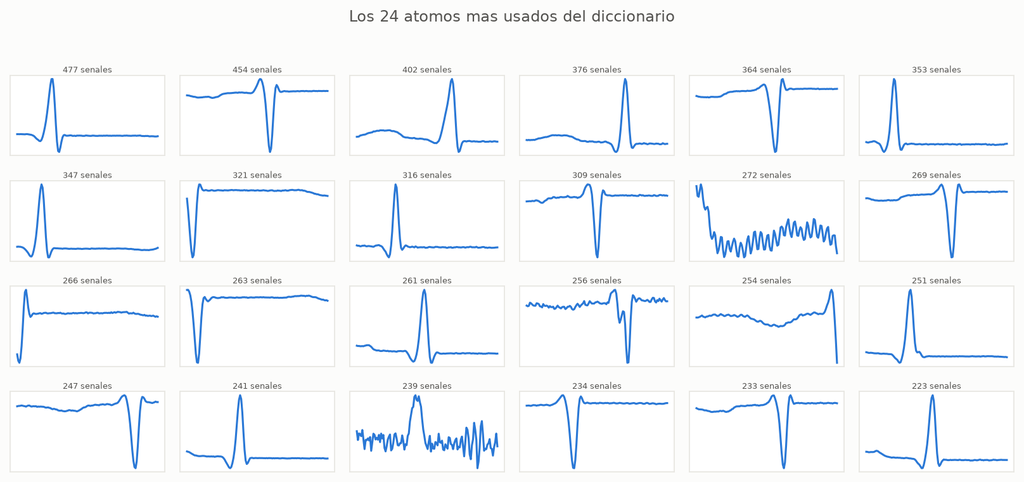

## Original contra reconstrucción

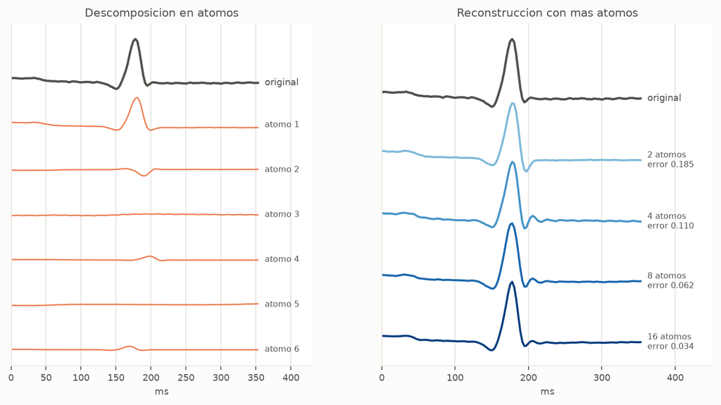

## Contra diccionarios que no aprendieron

[figure not shown]

1

2

4

8

16

32

0.0

0.2

0.4

0.6

0.8

átomos permitidos por ventana

error relativo sobre las ventanas de prueba

aprendido con K-SVD

D<sub>0</sub>: ventanas sin entrenar

DCT: diccionario fijo

Con 8 átomos: **0.130** contra 0.161 y 0.363. Donde importa, con pocos átomos, gana el aprendido.

Con 32 átomos la DCT lo alcanza: 0.074 contra 0.081.

## Cuánto se comprime

una ventana: 128 números

## Cuánto se comprime

9 pesos

9 índices de átomo

**18 números** en lugar de 128, con error cercano al 10 %

El diccionario se guarda una sola vez y lo comparten quien comprime y quien reconstruye

## Conclusiones

- K-SVD aprendió átomos con **la forma del latido**: con unos 9 de ellos una ventana de 128 muestras se reconstruye al 10 %
- Lo que mejora al entrenar es la **dispersión**, no el error: de 10.6 a 8.4 átomos para el mismo error
- Contra un diccionario fijo gana **donde importa**, con pocos átomos, y la ventaja desaparece cuando se permiten muchos
- Un diccionario de un paciente no cubre todas las morfologías: el siguiente paso es entrenar con varios
- La SVD no es una elección, es **la solución exacta** del paso de actualización: cada átomo es la mejor aproximación de rango 1 de lo que le toca explicar

## Referencias

- Aharon, M., Elad, M., y Bruckstein, A. (2006). K-SVD: An Algorithm for Designing Overcomplete Dictionaries for Sparse Representation. *IEEE Transactions on Signal Processing*, 54(11), 4311-4322.
- Pati, Y. C., Rezaiifar, R., y Krishnaprasad, P. S. (1993). Orthogonal Matching Pursuit: Recursive Function Approximation with Applications to Wavelet Decomposition. *27th Asilomar Conference on Signals, Systems and Computers*, 40-44.
- Eckart, C., y Young, G. (1936). The Approximation of One Matrix by Another of Lower Rank. *Psychometrika*, 1(3), 211-218.
- Moody, G. B., y Mark, R. G. (2001). The Impact of the MIT-BIH Arrhythmia Database. *IEEE Engineering in Medicine and Biology Magazine*, 20(3), 45-50.
- Goldberger, A. L., et al. (2000). PhysioBank, PhysioToolkit, and PhysioNet. *Circulation*, 101(23), e215-e220. https://physionet.org/content/mitdb/
- Visual Kernel. *SEE Matrix*, serie de videos en YouTube sobre matrices, descomposición espectral y SVD. https://www.youtube.com/playlist?list=PLWhu9osGd2dB9uMG5gKBARmk73oHUUQZS